# Question 5

2025-11-29

## Introduction

Understanding how economic perceptions shape mental and physical well-being is a central concern in the social sciences. Periods of economic uncertainty often coincide with higher levels of psychological distress, worsened health outcomes, and declining institutional trust. This analysis examines the relationship between Americans’ feelings of financial security and their self-reported mental health using data from the General Social Survey (GSS). The GSS provides one of the most comprehensive long-term datasets available for studying the attitudes, behaviors, and health outcomes of U.S. adults, making it uniquely well suited for evaluating how financial attitudes correspond to health-related quality of life.

Our investigation focuses on two dependent variables collected by the GSS:

1. mntlhlth – the number of days in the past 30 during which respondents experienced poor mental health.
2. hlthdays – the number of days during which poor health limited usual activities.

These are compared against three financial-attitude measures:

- confinan – confidence in financial institutions.
- satfin – satisfaction with one’s financial situation.
- finalter – whether the respondent feels financially better, worse, or the same compared to the previous year.

Because GSS health questions were not asked every year, the analysis focuses on years in which the mental-health and activity-limitation modules were administered. Mental-health data (mntlhlth) are available for 2002, 2004, 2006, 2010, 2012, 2014, 2016, 2018, and 2022, while activity-limitation data (hlthdays) appear for 2002, 2006, 2010, 2014, 2018, and 2022. Restricting the dataset to these years preserves comparability and avoids introducing bias from missing survey waves.

Negative values in GSS health variables represent nonvalid codes (such as “Inapplicable” or “Not asked”) rather than true values. These were recoded as NA to prevent them from being treated as genuine observations. The code below shows the initial data preparation, including numeric conversion, removal of invalid responses, and extraction of the relevant survey years.

```r
library(dplyr)
library(stringr)
library(tidyverse)
```

```r
library(ggplot2)
library(vcd)
library(patchwork)
library(lubridate)
library(tidyr)
library(car)
library(FSA)
GSS <- read.csv("Data/GSS.csv")


# Make every column character so we can filter reliably
GSS <- GSS %>% mutate(across(everything(), as.character))

GSS_clean <- GSS %>%

  # Race: keep only White, Black, Other
  mutate(race = ifelse(race %in% c("White", "Black", "Other"), race, NA)) %>%

  # Income: turn missing codes into NA
  mutate(income = ifelse(income %in% c(".i:  Inapplicable",
                                       ".d:  Do not Know/Cannot Choose",
                                       ".r:  Refused",
                                       ".n:  No answer",
                                       ".s:  Skipped on Web"),
                         NA, income)) %>%

  # Happy: keep only 3 valid levels, others to NA
  mutate(happy = ifelse(happy %in% c("Not too happy", "Pretty happy", "Very happy"),
                        happy, NA)) %>%

  # Confidence variables (each keeps only 3 valid responses)
  mutate(confinan  = ifelse(confinan  %in% c("A GREAT DEAL", "ONLY SOME", "HARDLY ANY"), confinan,  NA),
         conbus    = ifelse(conbus    %in% c("A GREAT DEAL", "ONLY SOME", "HARDLY ANY"), conbus,    NA),
         confed    = ifelse(confed    %in% c("A GREAT DEAL", "ONLY SOME", "HARDLY ANY"), confed,    NA),
         conlegis  = ifelse(conlegis  %in% c("A GREAT DEAL", "ONLY SOME", "HARDLY ANY"), conlegis,  NA)) %>%

  # Satisfaction with finances
  mutate(satfin = ifelse(satfin %in% c("Not satisfied at all",
                                       "More or less satisfied",
                                       "Pretty well satisfied"),
                         satfin, NA)) %>%

  # Financial alternatives
  mutate(finalter = ifelse(finalter %in% c("Better", "Stayed same", "Worse"),
                           finalter, NA)) %>%

  # Relative financial situation
  mutate(finrela = ifelse(finrela %in% c("AVERAGE", "ABOVE AVERAGE", "BELOW AVERAGE",
                                         "FAR ABOVE AVERAGE", "FAR BELOW AVERAGE"),
                          finrela, NA)) %>%

  # Mental health: turn missing codes into NA
  mutate(mntlhlth = ifelse(mntlhlth %in% c(".i:  Inapplicable",
                                           ".d:  Do not Know/Cannot Choose",
                                           ".n:  No answer"),
                           NA, mntlhlth)) %>%

  # Health days
  mutate(hlthdays = ifelse(hlthdays %in% c(".i:  Inapplicable",
                                           ".d:  Do not Know/Cannot Choose",
                                           ".n:  No answer"),
                           NA, hlthdays)) %>%

  mutate(natcrime = ifelse(natcrime %in% c(".i:  Inapplicable",
                                           ".d:  Do not Know/Cannot Choose",
                                           ".n:  No answer",
                                            ".s:  Skipped on Web"),
                           NA, natcrime)) %>%

  # Remove ballot variable as before
  select(-ballot)

GSS_mh <- GSS_clean %>%
  mutate(
    mntlhlth = as.numeric(mntlhlth),
    hlthdays = as.numeric(hlthdays)
  ) %>%
  mutate(
    mntlhlth = ifelse(mntlhlth < 0, NA, mntlhlth),
    hlthdays = ifelse(hlthdays < 0, NA, hlthdays)
  )

mh_years <- c(2002, 2004, 2006, 2010, 2012, 2014, 2016, 2018, 2022)

GSS_mntlhlth_years <- GSS_mh %>%
  filter(year %in% mh_years)

hd_years <- c(2002, 2006, 2010, 2014, 2018, 2022)

GSS_hlthdays_years <- GSS_mh %>%
  filter(year %in% hd_years)
```

To explore how mental-health outcomes vary across levels of financial trust, financial satisfaction, and perceived financial change, the analysis begins with visual summaries using side-by-side boxplots. These plots illustrate the distribution of mental-health days and health-limitation days within each financial-attitude category and provide an initial indication of whether meaningful differences are present.

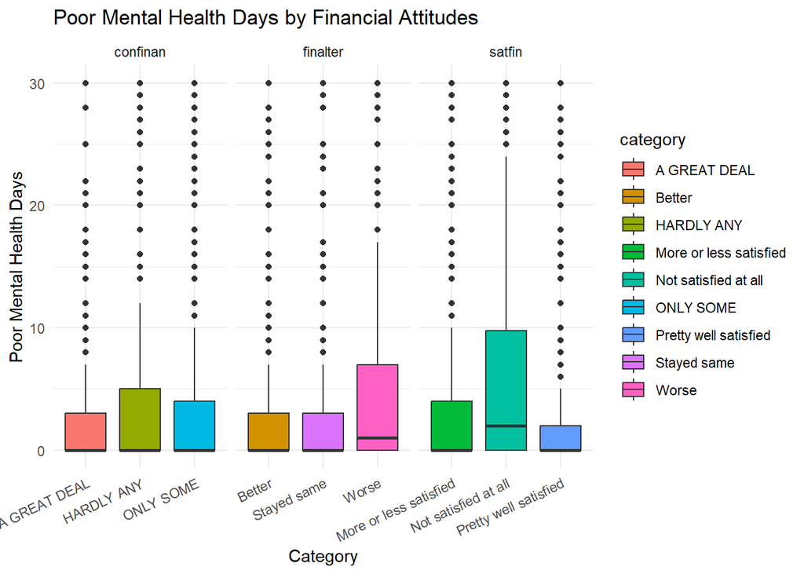

```r
GSS_mntlhlth_years %>%
  drop_na(confinan, satfin, finalter, mntlhlth) %>%
  pivot_longer(cols = c(confinan, satfin, finalter),
               names_to = "financial_var",
               values_to = "category") %>%
  ggplot(aes(x = category, y = mntlhlth, fill = category)) +
  geom_boxplot() +
  facet_wrap(~ financial_var, scales = "free_x") +
  labs(
    title = "Poor Mental Health Days by Financial Attitudes",
    x = "Category",
    y = "Poor Mental Health Days"
  ) +
  theme_minimal() +
  theme(axis.text.x = element_text(angle = 25, hjust = 1))
```

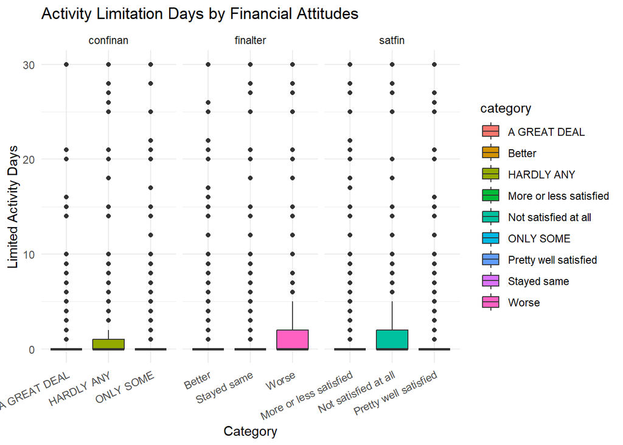

```r
GSS_hlthdays_years %>%
  drop_na(confinan, satfin, finalter, hlthdays) %>%
  pivot_longer(cols = c(confinan, satfin, finalter),
               names_to = "financial_var",
               values_to = "category") %>%
  ggplot(aes(x = category, y = hlthdays, fill = category)) +
  geom_boxplot() +
  facet_wrap(~ financial_var, scales = "free_x") +
  labs(
    title = "Activity Limitation Days by Financial Attitudes",
    x = "Category",
    y = "Limited Activity Days"
  ) +
  theme_minimal() +
  theme(axis.text.x = element_text(angle = 25, hjust = 1))
```

Because zero values in these variables reflect respondents who experienced no poor mental-health days or no activity-limitation days rather than missingness, analyses excluding zeros were also performed to examine the distributions among those who did experience symptoms.

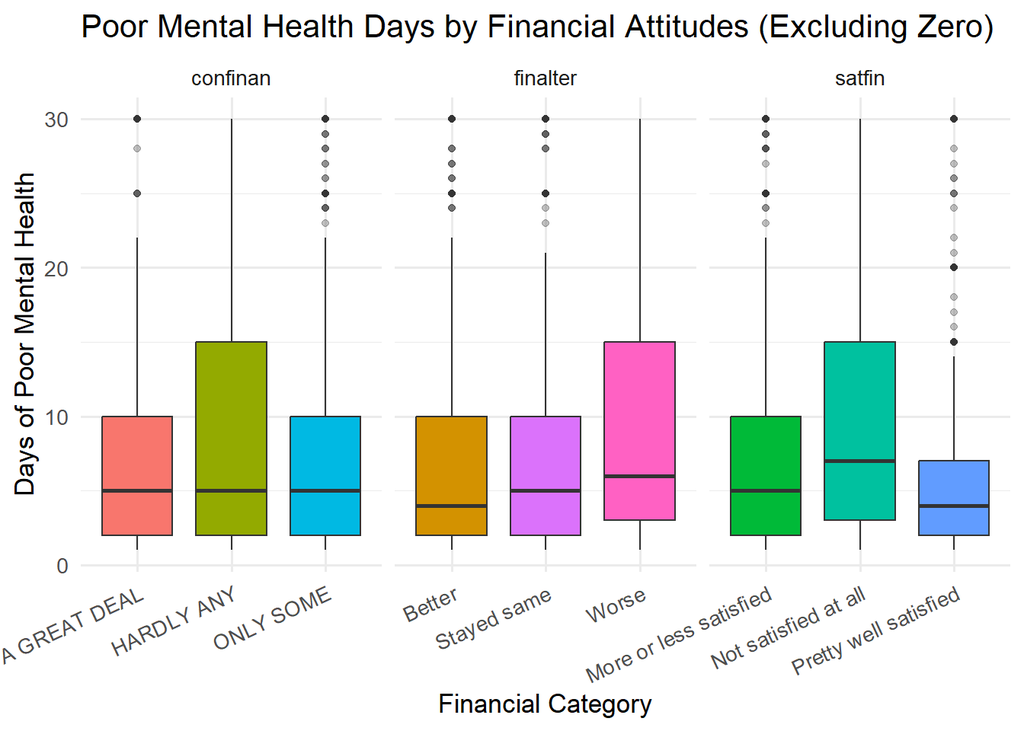

```r
GSS_mntlhlth_years %>%
  filter(!is.na(mntlhlth), mntlhlth > 0) %>%
  drop_na(confinan, satfin, finalter) %>%
  pivot_longer(
    cols = c(confinan, satfin, finalter),
    names_to = "financial_var",
    values_to = "category"
  ) %>%
  ggplot(aes(x = category, y = mntlhlth, fill = category)) +
  geom_boxplot(outlier.alpha = 0.3) +
  facet_wrap(~ financial_var, scales = "free_x") +
  labs(
    title = "Poor Mental Health Days by Financial Attitudes (Excluding Zero)",
    x = "Financial Category",
    y = "Days of Poor Mental Health"
  ) +
  theme_minimal(base_size = 13) +
  theme(
    axis.text.x = element_text(angle = 25, hjust = 1),
    legend.position = "none"
  )
```

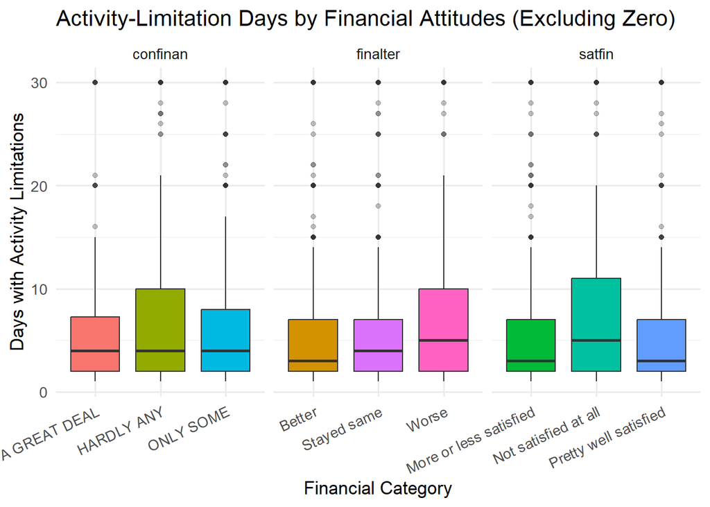

```r
GSS_hlthdays_years %>%
  filter(!is.na(hlthdays), hlthdays > 0) %>%
  drop_na(confinan, satfin, finalter) %>%
  pivot_longer(
    cols = c(confinan, satfin, finalter),
    names_to = "financial_var",
    values_to = "category"
  ) %>%
  ggplot(aes(x = category, y = hlthdays, fill = category)) +
  geom_boxplot(outlier.alpha = 0.3) +
  facet_wrap(~ financial_var, scales = "free_x") +
  labs(
    title = "Activity-Limitation Days by Financial Attitudes (Excluding Zero)",
    x = "Financial Category",
    y = "Days with Activity Limitations"
  ) +
  theme_minimal(base_size = 13) +
  theme(
    axis.text.x = element_text(angle = 25, hjust = 1),
    legend.position = "none"
  )
```

Before conducting statistical tests, normality and variance assumptions were evaluated. Shapiro–Wilk tests were applied within each financial‐attitude category. The results showed extremely small p-values (all < 0.001), indicating that the distribution of mental-health days is highly non-normal across all groups. Levene’s tests similarly revealed large and significant variance differences across categories of financial trust, satisfaction, and financial change. As a consequence, parametric tests such as ANOVA and t-tests would not be appropriate, and non-parametric approaches were used instead.

```r
# Shapiro test for each level of satfin
GSS_mntlhlth_years %>%
  filter(!is.na(mntlhlth), mntlhlth > 0) %>%
  group_by(satfin) %>%
  summarise(shapiro_p = shapiro.test(mntlhlth)$p.value)
```

```
## # A tibble: 4 × 2
##   satfin                 shapiro_p
##   <chr>                      <dbl>
## 1 More or less satisfied  6.36e-50
## 2 Not satisfied at all    7.75e-40
## 3 Pretty well satisfied   7.47e-40
## 4 <NA>                    1.43e-33
```

```r
# confinan
GSS_mntlhlth_years %>%
  filter(!is.na(mntlhlth), mntlhlth > 0) %>%
  group_by(confinan) %>%
  summarise(shapiro_p = shapiro.test(mntlhlth)$p.value)
```

```
## # A tibble: 4 × 2
##   confinan     shapiro_p
##   <chr>            <dbl>
## 1 A GREAT DEAL  1.07e-27
## 2 HARDLY ANY    5.71e-34
## 3 ONLY SOME     1.31e-46
## 4 <NA>          3.18e-50
```

```r
# finalter
GSS_mntlhlth_years %>%
  filter(!is.na(mntlhlth), mntlhlth > 0) %>%
  group_by(finalter) %>%
  summarise(shapiro_p = shapiro.test(mntlhlth)$p.value)
```

```
## # A tibble: 4 × 2
##   finalter    shapiro_p
##   <chr>           <dbl>
## 1 Better       1.45e-49
## 2 Stayed same  1.50e-43
## 3 Worse        7.27e-36
## 4 <NA>         1.59e-33
```

```r
leveneTest(mntlhlth ~ satfin, data = GSS_mntlhlth_years)
```

```
## Levene's Test for Homogeneity of Variance (center = median)
##          Df F value    Pr(>F)
## group     2   233.3 < 2.2e-16 ***
##       11387
## ---
## Signif. codes:  0 '***' 0.001 '**' 0.01 '*' 0.05 '.' 0.1 ' ' 1
```

```r
leveneTest(mntlhlth ~ confinan, data = GSS_mntlhlth_years)
```

```
## Levene's Test for Homogeneity of Variance (center = median)
##         Df F value    Pr(>F)
## group    2  21.163 6.819e-10 ***
##       7895
## ---
## Signif. codes:  0 '***' 0.001 '**' 0.01 '*' 0.05 '.' 0.1 ' ' 1
```

```r
leveneTest(mntlhlth ~ finalter, data = GSS_mntlhlth_years)
```

```
## Levene's Test for Homogeneity of Variance (center = median)
##          Df F value    Pr(>F)
## group     2  91.419 < 2.2e-16 ***
##       11384
## ---
## Signif. codes:  0 '***' 0.001 '**' 0.01 '*' 0.05 '.' 0.1 ' ' 1
```

Given these diagnostics, Kruskal–Wallis tests were performed to assess whether mental health and health-limitation days differ across financial-attitude groups.

```r
kruskal.test(mntlhlth ~ confinan,
             data = GSS_mntlhlth_years %>% filter(mntlhlth > 0))
```

```
##
##  Kruskal-Wallis rank sum test
##
## data:  mntlhlth by confinan
## Kruskal-Wallis chi-squared = 19.495, df = 2, p-value = 5.844e-05
```

```r
kruskal.test(mntlhlth ~ satfin,
             data = GSS_mntlhlth_years %>% filter(mntlhlth > 0))
```

```
##
##  Kruskal-Wallis rank sum test
##
## data:  mntlhlth by satfin
## Kruskal-Wallis chi-squared = 197.44, df = 2, p-value < 2.2e-16
```

```r
kruskal.test(mntlhlth ~ finalter,
             data = GSS_mntlhlth_years %>% filter(mntlhlth > 0))
```

```
##
##  Kruskal-Wallis rank sum test
##
## data:  mntlhlth by finalter
## Kruskal-Wallis chi-squared = 84.315, df = 2, p-value < 2.2e-16
```

```r
kruskal.test(hlthdays ~ confinan,
             data = GSS_hlthdays_years %>% filter(hlthdays > 0))
```

```
##
##  Kruskal-Wallis rank sum test
##
## data:  hlthdays by confinan
## Kruskal-Wallis chi-squared = 1.7835, df = 2, p-value = 0.4099
```

```r
kruskal.test(hlthdays ~ satfin,
             data = GSS_hlthdays_years %>% filter(hlthdays > 0))
```

```
##
##  Kruskal-Wallis rank sum test
##
## data:  hlthdays by satfin
## Kruskal-Wallis chi-squared = 64.001, df = 2, p-value = 1.266e-14
```

```r
kruskal.test(hlthdays ~ finalter,
             data = GSS_hlthdays_years %>% filter(hlthdays > 0))
```

```
##
##  Kruskal-Wallis rank sum test
##
## data:  hlthdays by finalter
## Kruskal-Wallis chi-squared = 47.422, df = 2, p-value = 5.041e-11
```

Where significant differences were detected, Dunn post-hoc tests with Bonferroni correction were used to determine which groups differed from one another.

```r
# mntlhlth vs. confinan
dunn_mntl_confinan <- dunnTest(
  mntlhlth ~ confinan,
  data = GSS_mntlhlth_years %>% filter(mntlhlth > 0),
  method = "bonferroni"
)
# mntlhlth vs. satfin
dunn_mntl_satfin <- dunnTest(
  mntlhlth ~ satfin,
  data = GSS_mntlhlth_years %>% filter(mntlhlth > 0),
  method = "bonferroni"
)
# mntlhlth vs. finalter
dunn_mntl_finalter <- dunnTest(
  mntlhlth ~ finalter,
  data = GSS_mntlhlth_years %>% filter(mntlhlth > 0),
  method = "bonferroni"
)
dunn_mntl_confinan
```

```
## Dunn (1964) Kruskal-Wallis multiple comparison
```

```
##   p-values adjusted with the Bonferroni method.
```

```
##                  Comparison          Z      P.unadj       P.adj
## 1 A GREAT DEAL - HARDLY ANY -3.4603831 5.394074e-04 0.001618222
## 2  A GREAT DEAL - ONLY SOME -0.5572564 5.773523e-01 1.000000000
## 3    HARDLY ANY - ONLY SOME  4.0552533 5.007999e-05 0.000150240
```

```r
dunn_mntl_satfin
```

```
## Dunn (1964) Kruskal-Wallis multiple comparison
##   p-values adjusted with the Bonferroni method.
```

```
##                                       Comparison         Z      P.unadj
## 1  More or less satisfied - Not satisfied at all -11.18888 4.622447e-29
## 2 More or less satisfied - Pretty well satisfied   3.79581 1.471621e-04
## 3   Not satisfied at all - Pretty well satisfied  12.81351 1.377622e-37
##          P.adj
## 1 1.386734e-28
## 2 4.414862e-04
## 3 4.132867e-37
```

```r
dunn_mntl_finalter
```

```
## Dunn (1964) Kruskal-Wallis multiple comparison
##   p-values adjusted with the Bonferroni method.
```

```
##             Comparison         Z      P.unadj        P.adj
## 1 Better - Stayed same -2.394304 1.665194e-02 4.995581e-02
## 2       Better - Worse -9.076446 1.121783e-19 3.365349e-19
## 3  Stayed same - Worse -6.491234 8.513592e-11 2.554078e-10
```

A parallel set of Dunn tests was used for activity-limitation days.

```r
# hlthdays vs. confinan
dunn_hlth_confinan <- dunnTest(
  hlthdays ~ confinan,
  data = GSS_hlthdays_years %>% filter(hlthdays > 0),
  method = "bonferroni"
)
# hlthdays vs. satfin
dunn_hlth_satfin <- dunnTest(
  hlthdays ~ satfin,
  data = GSS_hlthdays_years %>% filter(hlthdays > 0),
  method = "bonferroni"
)
# hlthdays vs. finalter
dunn_hlth_finalter <- dunnTest(
  hlthdays ~ finalter,
  data = GSS_hlthdays_years %>% filter(hlthdays > 0),
  method = "bonferroni"
)
dunn_hlth_confinan
```

```
## Dunn (1964) Kruskal-Wallis multiple comparison
```

```
##   p-values adjusted with the Bonferroni method.
```

```
##                  Comparison          Z   P.unadj     P.adj
## 1 A GREAT DEAL - HARDLY ANY -1.1708315 0.2416665 0.7249995
## 2  A GREAT DEAL - ONLY SOME -0.3882126 0.6978587 1.0000000
## 3    HARDLY ANY - ONLY SOME  1.1177213 0.2636860 0.7910581
```

```r
dunn_hlth_satfin
```

```
## Dunn (1964) Kruskal-Wallis multiple comparison
##   p-values adjusted with the Bonferroni method.
```

```
##                                       Comparison         Z      P.unadj
## 1  More or less satisfied - Not satisfied at all -6.891690 5.513358e-12
## 2 More or less satisfied - Pretty well satisfied  1.179954 2.380184e-01
## 3   Not satisfied at all - Pretty well satisfied  6.773831 1.254158e-11
##          P.adj
## 1 1.654007e-11
## 2 7.140553e-01
## 3 3.762475e-11
```

```r
dunn_hlth_finalter
```

```
## Dunn (1964) Kruskal-Wallis multiple comparison
##   p-values adjusted with the Bonferroni method.
```

```
##             Comparison         Z      P.unadj        P.adj
## 1 Better - Stayed same -2.339297 1.932009e-02 5.796027e-02
## 2       Better - Worse -6.861440 6.816975e-12 2.045093e-11
## 3  Stayed same - Worse -4.430002 9.423226e-06 2.826968e-05
```

Finally, ordinal-to-numeric recoding allowed Spearman rank correlations to be computed between financial attitudes and health outcomes. These correlations provide a measure of strength and direction without assuming linearity or normality.

```r
GSS_hlthdays_years_num  <- GSS_mntlhlth_years %>%
  filter(mntlhlth > 0) %>%
  mutate(
    confinan_num = case_match(
      confinan,
      "HARDLY ANY" ~ 1,
      "ONLY SOME" ~ 2,
      "A GREAT DEAL" ~ 3,
      .default = NA
    ),

    satfin_num = case_match(
      satfin,
      "Not satisfied at all" ~ 1,
      "More or less satisfied" ~ 2,
      "Pretty well satisfied" ~ 3,
      .default = NA
    ),

    finalter_num = case_match(
      finalter,
      "Worse" ~ 1,
      "Stayed same" ~ 2,
      "Better" ~ 3,
      .default = NA
    )
  )

cor.test(GSS_hlthdays_years_num$hlthdays,
         GSS_hlthdays_years_num$confinan_num,
         method = "spearman")
```

```
##
##  Spearman's rank correlation rho
##
## data:  GSS_hlthdays_years_num$hlthdays and GSS_hlthdays_years_num$confinan_num
## S = 2129544082, p-value = 0.0001114
## alternative hypothesis: true rho is not equal to 0
## sample estimates:
##         rho
## -0.08087833
```

```r
cor.test(GSS_hlthdays_years_num$hlthdays,
         GSS_hlthdays_years_num$satfin_num,
         method = "spearman")
```

```
##
##  Spearman's rank correlation rho
##
## data:  GSS_hlthdays_years_num$hlthdays and GSS_hlthdays_years_num$satfin_num
## S = 7589798982, p-value = 1.925e-12
## alternative hypothesis: true rho is not equal to 0
## sample estimates:
##        rho
## -0.1196571
```

```r
cor.test(GSS_hlthdays_years_num$hlthdays,
         GSS_hlthdays_years_num$finalter_num,
         method = "spearman")
```

```
##
##  Spearman's rank correlation rho
##
## data:  GSS_hlthdays_years_num$hlthdays and GSS_hlthdays_years_num$finalter_num
## S = 7473813358, p-value = 8.284e-10
## alternative hypothesis: true rho is not equal to 0
## sample estimates:
##        rho
## -0.1044726
```

## Visualization of Mental Health and Financial Attitudes

To begin evaluating how financial trust and financial well-being relate to mental health, we first examined distributional differences in mental health outcomes across categories of financial confidence, financial satisfaction, and perceived financial trajectory. We used two measures of mental health that the GSS collects: the number of poor mental health days (mntlhlth) and the number of activity-limitation days (hlthdays). Because both variables represent counts of days within the past month, many respondents reported zero days. We therefore present results twice: once with all non-missing values and once with zero values excluded, since zero often reflects an absence of symptoms rather than variation in severity.

### 1. Poor Mental Health Days by Financial Attitudes (All Values Included)

**Finding:** The first figure shows that respondents with lower trust in financial institutions, poorer financial satisfaction, and worse year-to-year financial change tend to experience more poor mental health days.

Overall, the figure suggests a clear gradient: as financial well-being indicators worsen, the distribution of poor mental health days shifts upward.

### 2. Activity Limitation Days by Financial Attitudes (All Values Included)

These results indicate that financial strain and lack of confidence correspond not only to emotional distress but also to measurable physical or functional limitations.

### 3. Poor Mental Health Days by Financial Attitudes (Zero Excluded)

The exclusion of zeros reveals a sharper contrast in distributions, strengthening the argument that financial insecurity is linked to elevated mental health burdens among those who experience symptoms.

### 4. Activity Limitation Days by Financial Attitudes (Zero Excluded)

This consistency across two different health measures indicates that the relationship between financial security and health is not limited to a single domain. Financial stress appears to affect both emotional well-being and the ability to perform usual daily activities.

## Statistical Testing of Mental Health and Financial Attitudes

### 1. Normality and Variance Diagnostics

Given these violations, we proceeded with non-parametric analyses.

### 2. Kruskal–Wallis Tests

**Poor Mental Health Days (mntlhlth)**

For respondents reporting at least one poor mental health day, all three financial variables showed significant differences across categories:

- Confidence in financial institutions: H(2) = 19.50, p = 5.8e-05
- Financial satisfaction: H(2) = 197.44, p < 2.2e-16
- Perceived financial change: H(2) = 84.32, p < 2.2e-16

These results indicate that poor mental health days differ systematically depending on financial confidence, satisfaction, and whether finances improved, stayed the same, or became worse.

**Activity-Limitation Days (hlthdays)**

For activity-limitation days, two of the three variables showed significant differences:

- Confidence in financial institutions: H(2) = 1.78, p = 0.41 (not significant)
- Financial satisfaction: H(2) = 64.00, p = 1.27e-14
- Perceived financial change: H(2) = 47.42, p = 5.04e-11

These results show that activity-limitation days vary by financial satisfaction and by perceived financial change, but not by trust in financial institutions.

### 3. Dunn Post-Hoc Tests

#### Mental Health Days

**Financial confidence:** Significant pairwise differences emerged between

- “A Great Deal” vs “Hardly Any” (p = 0.0016)
- “Hardly Any” vs “Only Some” (p = 0.00015)

The contrast between “A Great Deal” and “Only Some” was not significant. This pattern suggests that the largest differences occur between the most skeptical group and the others.

**Financial satisfaction:** All three pairwise comparisons were significant after adjustment:

- “More or less satisfied” vs “Not satisfied at all” (p ≈ 1.4e-28)
- “More or less satisfied” vs “Pretty well satisfied” (p ≈ 4.4e-04)
- “Not satisfied at all” vs “Pretty well satisfied” (p ≈ 4.1e-37)

This is a very strong gradient, with dissatisfaction associated with sharply worse mental health outcomes.

**Perceived financial change:** All comparisons were significant:

- “Better” vs “Stayed the same” (p ≈ 0.0499)
- “Better” vs “Worse” (p ≈ 3.4e-19)
- “Stayed the same” vs “Worse” (p ≈ 2.6e-10)

People whose financial situation worsened report much higher mental health burdens.

#### Activity-Limitation Days

**Financial confidence:** None of the pairwise contrasts were significant (all adjusted p > 0.72). This is consistent with the non-significant Kruskal result.

**Financial satisfaction:** Significant differences were found between

- “More or less satisfied” vs “Not satisfied at all” (p ≈ 1.6e-11)
- “Not satisfied at all” vs “Pretty well satisfied” (p ≈ 3.8e-11)

There was no significant difference between “More or less satisfied” and “Pretty well satisfied.”

**Perceived financial change:** Two pairwise comparisons were significant:

- “Better” vs “Worse” (p ≈ 2.0e-11)
- “Stayed the same” vs “Worse” (p ≈ 2.8e-05)

The comparison between “Better” and “Stayed the same” was not significant after correction. People whose finances worsened have the highest activity-limitation burdens.

### Summary of Statistical Findings

Across every analysis, one pattern appears repeatedly. People who feel financially insecure, financially dissatisfied, or financially worse off report higher levels of mental health distress and more days of physical limitation. The strongest associations involve financial satisfaction and financial trajectory, which consistently show large differences between groups and highly significant results in all non-parametric tests and correlations.

Trust in financial institutions shows weaker patterns. It is meaningfully related to poor mental health days but not to days of physical limitation. This suggests that the subjective experience of one’s own financial situation plays a larger role in mental and physical health than trust in the broader financial system.